# MG205: Econometrics Theory and Applications

Empirical Exercise 4: Income Inequality

Jose Ignacio Gonzalez-Rojas

j.i.gonzalez-rojas@lse.ac.uk

London School of Economics and Political Science

## Today: From Association to Causation

### Agenda

#### Today’s Roadmap

1. Inequality May Cause Social Problems
2. Statistical Significance Requires Interpretation
3. Association Does Not Imply Causation

#### Term 1 Recap

- **Identification:** Can we learn causal parameters from data?
- **Estimation:** OLS properties (unbiasedness, consistency)
- **Inference:** Hypothesis testing, confidence intervals, p-values

Today: Apply these tools to a real policy debate

# Inequality May Cause Social Problems

## Redistribution Could Solve Multiple Problems at Once

### The Policy Stakes

#### Wilkinson and Pickett (2009)

*The Spirit Level: Why Equality is Better for Everyone*

- Income inequality **causes** social problems through psychological mechanisms:
  - Status anxiety increases stress
  - Social trust deteriorates
  - Health outcomes worsen

#### Policy Implications

If true, redistribution policies would:

- Improve health outcomes
- Reduce crime and imprisonment
- Increase educational achievement
- Build social trust

One policy lever, multiple benefits

### From Japan to Singapore

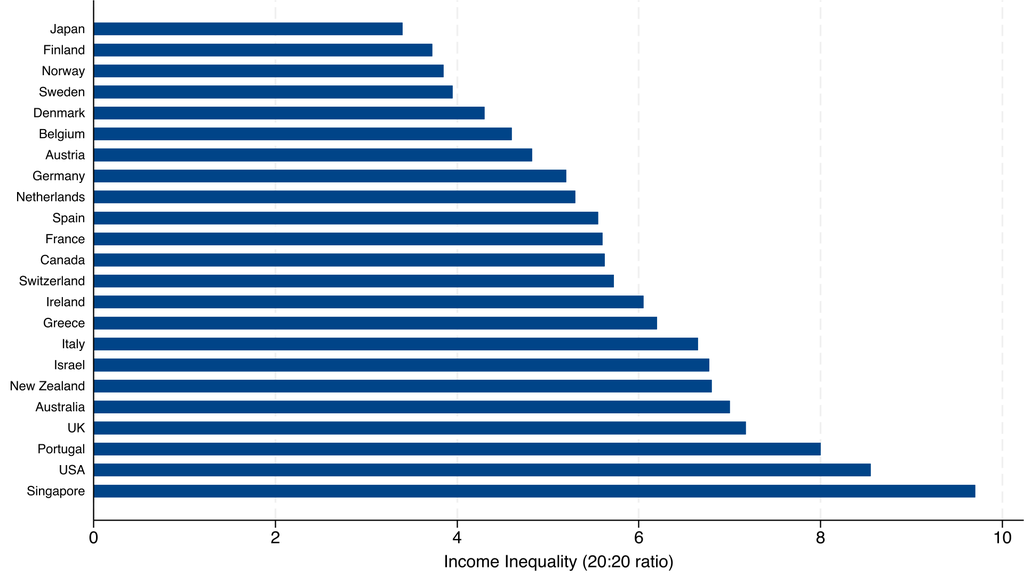

## Inequality Associates with Worse Social Outcomes

### Patterns Across Multiple Variables

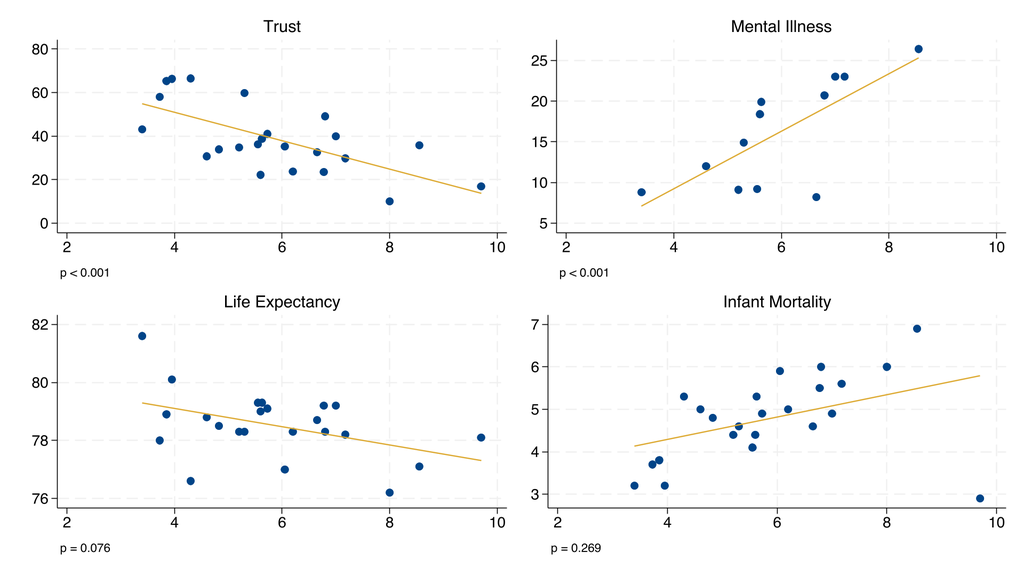

## Most Relationships Are Statistically Significant

### Regressions of each outcome on inequality

| Outcome | Coefficient | p-value | N |
| --- | --- | --- | --- |
| Trust | -6.54 | 0.000 | 23 |
| Mental Illness | +3.50 | 0.004 | 12 |
| Imprisonment | +0.29 | 0.001 | 23 |
| Child Conflict | +0.28 | 0.006 | 19 |
| Teenage Births | +5.86 | 0.003 | 21 |
| Drug Use Index | +0.34 | 0.009 | 22 |

| Outcome | Coefficient | p-value | N |
| --- | --- | --- | --- |
| Obesity | +2.69 | 0.020 | 21 |
| Maths/Literacy | -8.09 | 0.042 | 21 |
| Life Expectancy | -0.31 | 0.084 | 23 |
| Infant Mortality | +0.26 | 0.263 | 23 |
| Homicides | +1.84 | 0.385 | 23 |

# Statistical Significance Requires Interpretation

## Under the Null, This Pattern Would Be Extremely Unlikely

### The Logic of Hypothesis Testing

#### The Hypothesis Test

$$H_0: \beta_1 = 0 \quad \text{(no relationship)}$$

If inequality truly had no effect, how likely would we observe coefficients this large?

Under $H_0$, with probability $p$ an outcome this extreme would occur.

But statistical significance is not causal evidence

## Large Effects Overcome Small Sample Limitations

$$\text{var}(\hat{\beta}) = \frac{\sigma^2}{n}\cdot\frac{1}{\text{var}(x_{i})}$$

#### Small Sample Challenges

- Small $n$ implies large critical value $c$
- Small denominator implies large SE
- Both make rejection harder

#### Yet We Still Reject

- With only 12-23 observations
- We still find significance
- The effect must be large

## Critics Accused WP of Cherry-Picking Variables

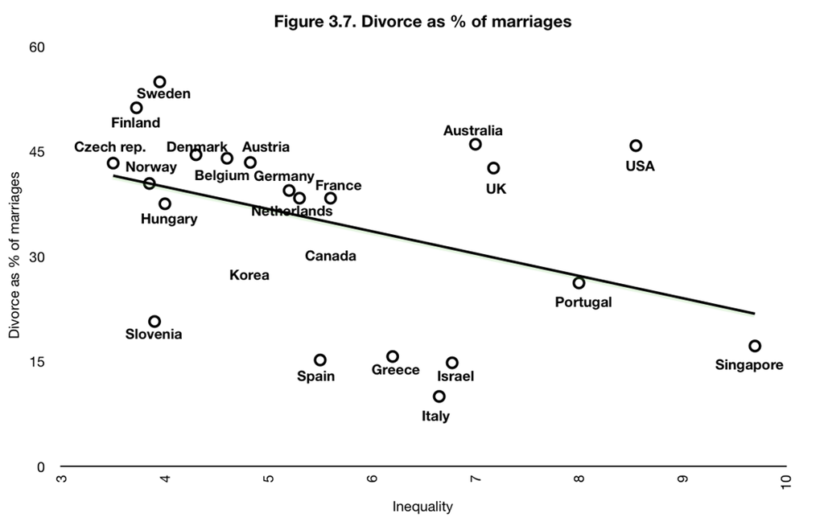

Divorce as % of marriages

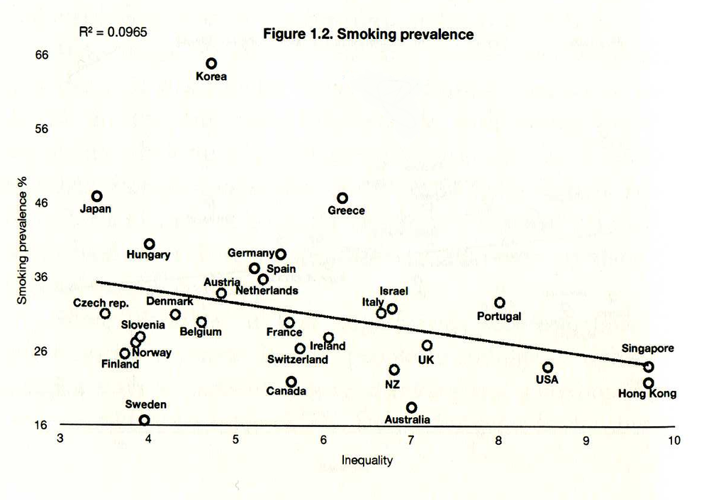

Smoking prevalence

## External Indices Provide Scientific Credibility

### UNICEF vs. Author-Created Measures

#### The Cherry-Picking Critique

- Authors could select only variables that support their thesis
- **P-hacking:**
  - Running many tests
  - Reporting only significant ones
- Fabricating composite indices to get desired results

#### The Defense

- **UNICEF child well-being index:** externally created
- Authors cannot manipulate its construction
- Still shows strong correlation with inequality

Pre-existing indices provide credibility against cherry-picking

## Several Relationships Are Driven by Outlying Countries

### Sensitivity Analysis

Some relationships may be driven by extreme observations:

### Robustness check

- Remove outliers and re-estimate
  - If coefficients change dramatically, results are fragile.

#### What Changes?

| Outcome | Robust? |
| --- | --- |
| Trust | Yes |
| Mental Illness | Sensitive |
| Imprisonment | Sensitive to USA |
| Obesity | Yes |

Always check sensitivity to outliers

# Association Does Not Imply Causation

## Omitted Variables Could Explain the Entire Pattern

### Culture as a Potential Confounder

#### The Omitted Variable Problem

- Cultural factors might cause both:
  - Higher inequality (less redistribution)
  - More social problems (individualism)
- If so, the correlation is spurious.

#### Confounder DAG

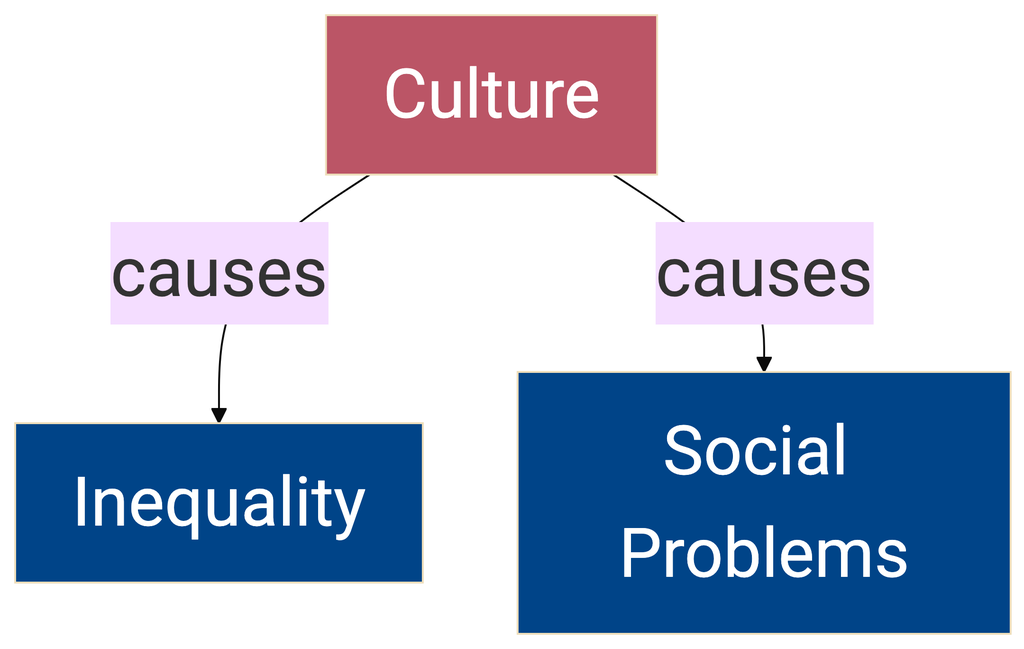

Control for confounders to isolate causal effect

## Never Control for Variables in the Causal Chain

### The Mediator Trap

**Stress is part of the causal pathway**

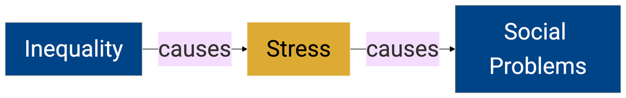

- Controlling for stress would **block** the effect we want to measure.
- This is the **opposite** of what we do with confounders.

## Confounders and Mediators Require Opposite Treatment

### A Critical Distinction

#### Confounder: CONTROL

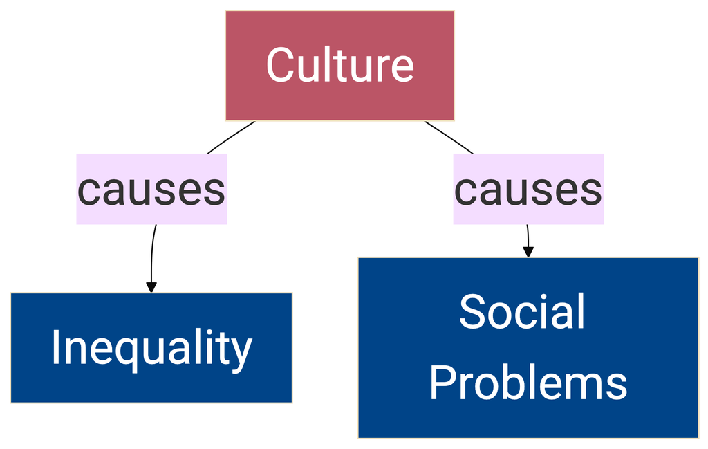

- Opens a backdoor path
- Creates spurious correlation
- **Solution:** Control for Confounder

#### Mediator: DO NOT CONTROL

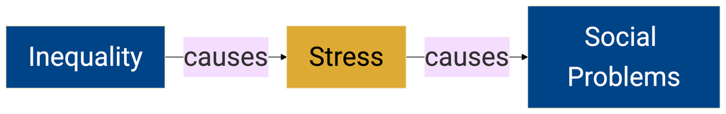

- Part of causal mechanism
- Blocking removes true effect
- **Solution:** Leave Mediator out

## US States Offer Different Trade-offs

### Alternative Research Designs

#### Cross-Country Analysis

- **Advantages:**
  - Large variation in inequality
  - Policy-relevant comparisons
- **Disadvantages:**
  - Only 20-25 observations
  - Cultural confounding
  - Different institutions

#### US States Analysis

- **Advantages:**
  - 50 observations
  - Common institutions
  - Similar culture
- **Disadvantages:**
  - Less variation in inequality
  - State-specific confounders
  - Internal migration

Different designs answer similar questions with different assumptions

## Four Key Lessons from the Inequality Debate

### What to Remember

1. **Large effects** can overcome small sample limitations
   - Variance formula explains why significance is possible
2. **External indices** provide credibility against cherry-picking
   - UNICEF index cannot be manipulated by researchers
3. **Omitted confounders** threaten causal interpretation
   - Culture could explain both inequality and outcomes
4. **Never control for mediators** in the causal chain
   - Stress is part of the mechanism, not a confounder

## Next Week: Beauty

### Empirical Exercise 5

**Mobius and Rosenblat (2006, AER)**

- Why beauty matters: decomposing the beauty premium
- Experimental design with 5 treatments (330 students)
- Channels: productivity, confidence, visual and oral stereotypes
- Key finding: beauty works through stereotypes, not productivity